# Tarea: Intervalos

Ramon Ceballos

1/4/2021

## 1. Resuelve las siguientes inecuaciones:

*a. $|x-1|<3$*

Resolvemos la desigualdad obteniendo dos intervalos que cumplen la condición descrita: $x<4$ y $x>-2$. Por tanto, la solución de la inecuación será el intervalo $(-2,4)$.

Vamos a determinar su resolución a través de código Python.

```python
import sympy as sp

x = sp.symbols("x")
expr = abs(x-1)

result = sp.solvers.inequalities.solve_univariate_inequality(expr<3,x)

print(result)
```

```
## (-2 < x) & (x < 4)
```

*b. $|2-3x|<1$*

Resolvemos la desigualdad obteniendo dos intervalos que cumplen la condición descrita: $x<1$ y $x>\frac{1}{3}$. Por tanto, la solución de la inecuación será el intervalo $(\frac{1}{3},1)$.

Vamos a determinar su resolución a través de código Python.

```python
import sympy as sp

x = sp.symbols("x")
expr = abs(2-3*x)

result = sp.solvers.inequalities.solve_univariate_inequality(expr<1,x)

print(result)
```

```
## (1/3 < x) & (x < 1)
```

*c. $|x-2|>3$*

Resolvemos la desigualdad obteniendo dos intervalos que cumplen la condición descrita: $x<-1$ y $x>5$. Por tanto, la solución de la inecuación será el intervalo $(-\infty,-1) \cup (5,+\infty)$.

Vamos a determinar su resolución a través de código Python.

```python
import sympy as sp

x = sp.symbols("x")
expr = abs(x-2)

result = sp.solvers.inequalities.solve_univariate_inequality(expr>3,x)

print(result)
```

```
## ((-oo < x) & (x < -1)) | ((5 < x) & (x < oo))
```

## 2. Resuelve analiticamente y graficamente las siguientes inecuaciones:

*a. $|5-\frac{1}{x}|<1$*

Vamos a determinar su resolución a través de código Python.

```python
import sympy as sp

x = sp.symbols("x")
expr = abs(5-(1/x))

result = sp.solvers.inequalities.solve_univariate_inequality(expr<1,x)

print(result)
```

```
## (1/6 < x) & (x < 1/4)
```

El intervalo que resuelve la inecuación será por tanto: $(\frac{1}{6},\frac{1}{4})$.

```python
import numpy as np
import matplotlib.pyplot as plt
x = np.linspace(1,-1,1000)
def f (x):
  return abs(5-(1/x))
plt.plot(x, f(x),color="black",linewidth=2)
plt.axhline(1,0,color="red")
plt.axhline(0,0,color="black")
plt.ylim(-0.5,10)
```

```
## (-0.5, 10.0)
```

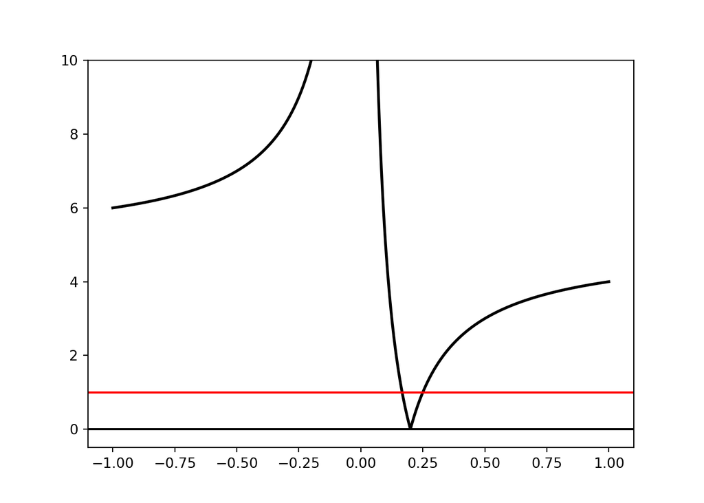

```python
plt.show()
```

*b. $|x^2-2|\le 2$*

Se cumple que $|x^2-2|\le 2$, si y solo si, $-2\le x^2-2\le 2$, es decir, si $0\le x^2\le 4$.

Vamos a determinar su resolución a través de código Python.

```python
import sympy as sp

x = sp.symbols("x")
expr = abs(x**2-2)

result = sp.solvers.inequalities.solve_univariate_inequality(expr<=2,x)

print(result)
```

```
## (-2 <= x) & (x <= 2)
```

El intervalo que resuelve la inecuación será por tanto: $[-2,2]$.

```python
import numpy as np
import matplotlib.pyplot as plt
x = np.linspace(10,-10,1000)
def f (x):
  return abs(x**2-2)
plt.plot(x, f(x),color="black",linewidth=2)
plt.axhline(2,0,color="red")
plt.axhline(0,0,color="black")
plt.ylim(-0.5,4)
```

```
## (-0.5, 4.0)
```

```python
plt.xlim(-4,4)
```

```
## (-4.0, 4.0)
```

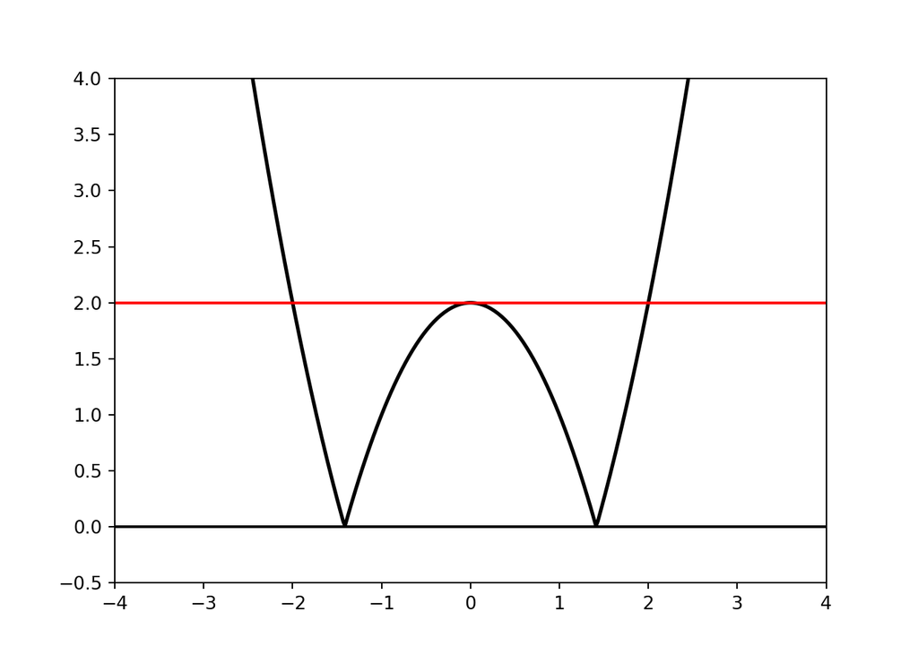

```python
plt.show()
```

## 3. Resuelve analiticamente y graficamente la inecuacion:

Tenemos la inecuación $|x-4|<|x+2|$.

Partiendo de que $|x|^2 = x^2$, entonces deducimos que:

$$(|x-4|)^2<(|x+2|)^2$$
$$x^2-8x+16<x^2+4x+4$$
$$12x>12\ \rightarrow\ x>1$$

Se deduce que le intervalo que resuelve la inecuación para $x$ es $(1,+\infty)$.

Vamos a determinar su resolución a través de código Python.

```python
import sympy as sp

x = sp.symbols("x")
expr1 = abs(x-4)
expr2 =abs(x+2)

result = sp.solvers.inequalities.solve_univariate_inequality(expr1<expr2,x)

print(result)
```

```
## (1 < x) & (x < oo)
```

```python
import numpy as np
import matplotlib.pyplot as plt
x = np.linspace(10,-10,1000)
def f1 (x):
  return abs(x-4)
def f2 (x):
  return abs(x+2)
plt.plot(x, f1(x),color="black",linewidth=2,label="|x-4|")
plt.plot(x, f2(x),color="blue",linewidth=2, label="|x+2|")
plt.axhline(0,0,color="black")
plt.axvline(1,0,color="red")
plt.ylim(-0.5,10)
```

```
## (-0.5, 10.0)
```

```python
plt.xlim(-10,10)
```

```
## (-10.0, 10.0)
```

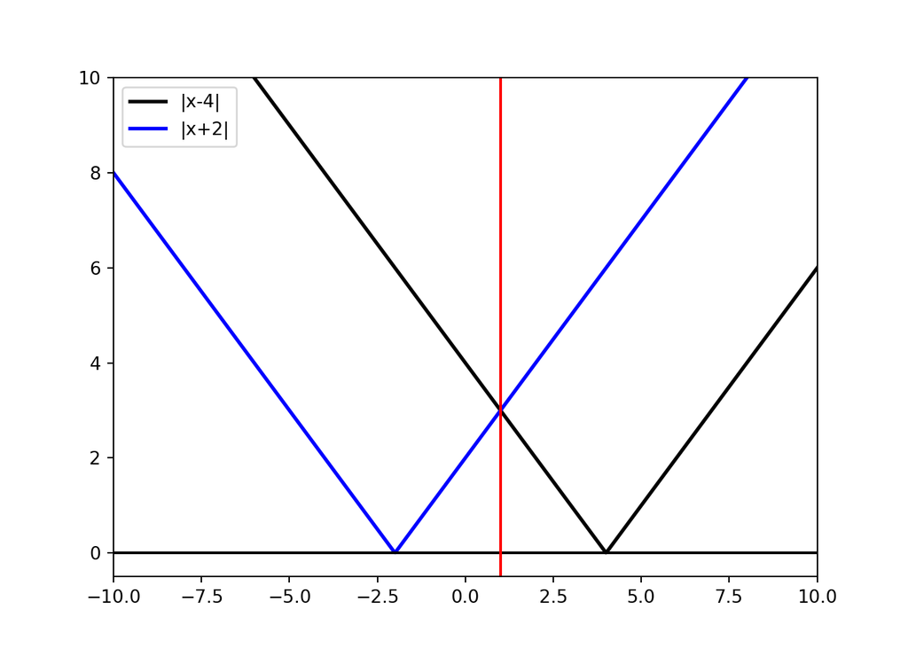

```python
plt.legend()
plt.show()
```

## 4. Resuelve la siguiente inecuacion:

Tenemos: $x<x^2-12<3x$

Hemos de resolver dos inecuaciones para luego realziar una intersección de lo obtenido en ambas.

En el primer caso $x<x^2-12$, al resolver la inecuación de segundo grado se obtiene que la variable $x$ debe cumplir: $x<-3$ y $x>4$. Por tanto el intervalo que resuelve esta primera parte es $(-\infty,-3)\ \cup \ (4,+\infty)$.

En el segundo caso $x^2-12<3x$, al resolver esta inecuación de segundo grado se obtiene que la variable $x$ debe cumplir: $x<\frac{3+\sqrt{57}}{2}$ y $x>\frac{3-\sqrt{57}}{2}$. Por tanto, el intervalo que resuelve este apartado es $(\frac{3-\sqrt{57}}{2},\frac{3+\sqrt{57}}{2})$

Si hacemos la intersección entre ambos resultados $(-\infty,-3)\ \cup \ (4,+\infty)\ \cap \ (\frac{3-\sqrt{57}}{2},\frac{3+\sqrt{57}}{2})$, obtenemos que el intervalo que resuelve la expresión pedida en el ejercicio es $(4,\frac{3+\sqrt{57}}{2})$.

Vamos a determinar su resolución a través de código Python.

```python
import sympy as sp

x = sp.symbols("x")
expr1 = x
expr2 = (x**2)-12
expr3 = 3*x

result1 = sp.solvers.inequalities.solve_univariate_inequality(expr1<expr2,x)
print(result1)
```

```
## ((-oo < x) & (x < -3)) | ((4 < x) & (x < oo))
```

```python
result2 = sp.solvers.inequalities.solve_univariate_inequality(expr2<expr3,x)
print(result2)
```

```
## (x < 3/2 + sqrt(57)/2) & (3/2 - sqrt(57)/2 < x)
```

Vemos las gráficas de cada uno de las inecuaciones planteadas, para uego hacer una intersección.

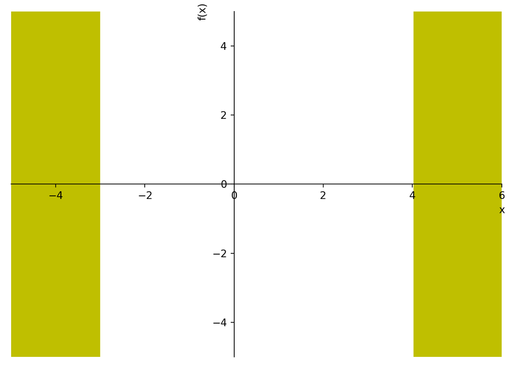

```python
p1 = sp.plotting.plot_implicit(x<(x**2)-12,(x,-5.,6.),line_color="y")
```

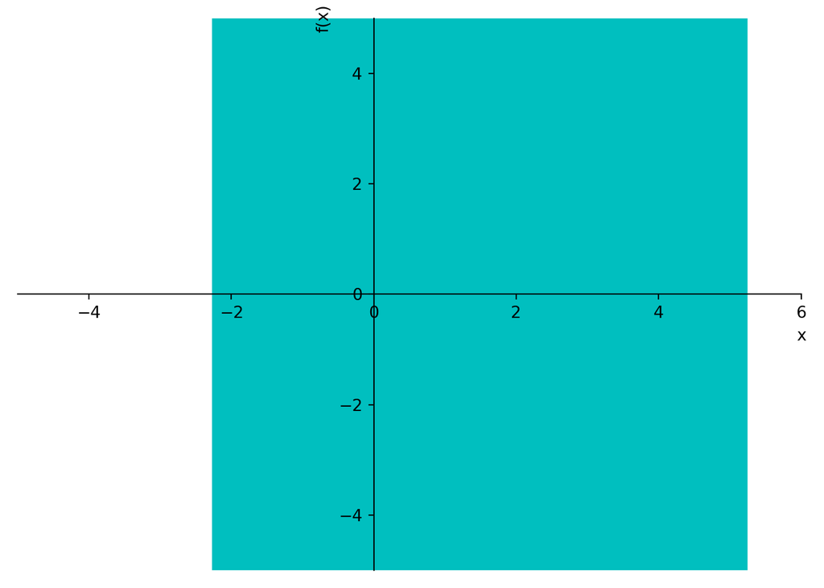

```python
p2 = sp.plotting.plot_implicit((x**2)-12<3*x,(x,-5.,6.),line_color="c")
```

## 5. Resuelve la siguiente inecuacion:

Tenemos: $0<|x-3|<\frac{1}{3}$

Vamos a determinar su resolución a través de código Python.

```python
import sympy as sp

x = sp.symbols("x")
expr1 = abs(x-3)

result1 = sp.solvers.inequalities.solve_univariate_inequality(expr1>0,x)
print(result1)
```

```
## (x > -oo) & (x < oo) & Ne(x, 3)
```

```python
result2 = sp.solvers.inequalities.solve_univariate_inequality(expr1<1/3,x)
print(result2)
```

```
## (2.66666666666667 < x) & (x < 3.33333333333333)
```

## 6. Resuelve la siguiente inecuacion:

Tenemos: $|x-2|+|x+2|\le 4$.

Vamos a determinar su resolución a través de código Python para graficarlo.

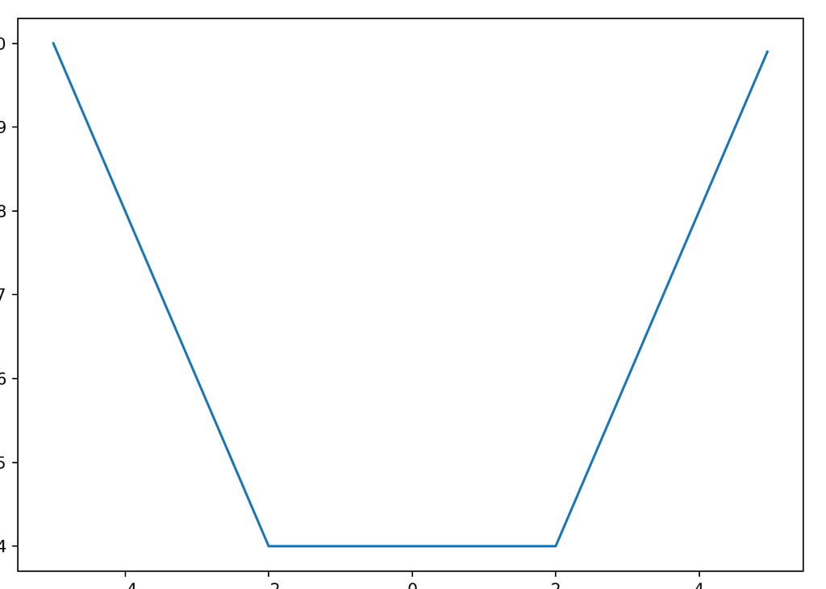

```python
import matplotlib.pyplot as plt
import numpy as np

x = np.arange(-5,5,0.05)
y = abs(x-2) + abs(x+2)

plt.plot(x,y)
plt.show()
```

## 7. Resuelve las siguientes inecuaciones:

*a. $|x^2-3|>1$*

Partimos de la inecuación de segundo grado $|x^2-3|>1$.

Para la resolución de la inecuación es mejor partir de la siguiente expresión $|x^2-3|\le1$, la cual al desarrollarla obtenemos: $2<x^2<4$.

Se observa que hay cuatro puntos donde la ecuación varía siendo mayor o menor de 1, estos puntos son $-\sqrt{2},\sqrt{2},-2,2$.

Atendiendo a dichos puntos descritos la expresión $|x^2-3|>1$ se cumplirá en el intervalo $(-\infty,-2)\ \cup\ (\sqrt{-2},\sqrt{2})\ \cup\ (2,+\infty)$.

Vamos a determinar su resolución a través de código Python.

```python
import sympy as sp

x = sp.symbols("x")
expr1 = abs((x**2)-3)


result1 = sp.solvers.inequalities.solve_univariate_inequality(expr1>1,x)
print(result1)
```

```
## ((-oo < x) & (x < -2)) | ((2 < x) & (x < oo)) | ((x < sqrt(2)) & (-sqrt(2) < x))
```

*b. $|x^2-x+1|>1$*

Al igual que en el ejemplo $a$ partimos de la expresión $|x^2-x+1|<1$. Tenemos la expresión siguiente al desarrollar $-1<x^2-x+1<1$.

Resolvemos cada parte de la inecuación obtenida. La primera parte, $-1<x^2-x+1$, no presenta soluciones reales al resolver, siendo positiva para todo $\mathbb{R}$. En cuanto a la segunda parte de la inecuación, $x^2-x+1<1$, se obtienen dos soluciones (0,1). Estudiando los intervalos que forman se obtiene que el intervalo solución de la inecuación es $(-\infty,0)\ \cup\ (1,+\infty)$.

Vamos a determinar su resolución a través de código Python.

```python
import sympy as sp

x = sp.symbols("x")
expr1 = abs((x**2)-x+1)


result1 = sp.solvers.inequalities.solve_univariate_inequality(expr1>1,x)
print(result1)
```

```
## ((-oo < x) & (x < 0)) | ((1 < x) & (x < oo))
```

## 8. Resuelve la siguiente inecuacion:

La inecuación es $\frac{|x-4|}{|x^2+5|}<1$.

Se discierne que el denominador de la ecuacíon nunca puede ser cero, podemos poner la siguiente expresión $|x-4|<|x^2+5|$. Si resolvemos, discenimos que no hay solución en la recta real, por tanto el conjunto estudiado o es cierto para todo $\mathbb{R}$ o no lo es. Si sustituimos se comprueba facilmente que la solución de la inecuación es toda la recta real, el intervalo $(-\infty,+\infty)$.

Vamos a determinar su resolución a través de código Python.

```python
import sympy as sp

x = sp.var("x")
expr = abs(x-4)/abs((x**2)+5)


result1 = sp.solvers.inequalities.solve_univariate_inequality(expr<1,x)
print(result1)
```

```
## (-oo < x) & (x < oo)
```

## 9. Representa graficamente los conjuntos de puntos (x, y) tales que:

*a. x>y*

Vamos a determinar su resolución a través de código Python.

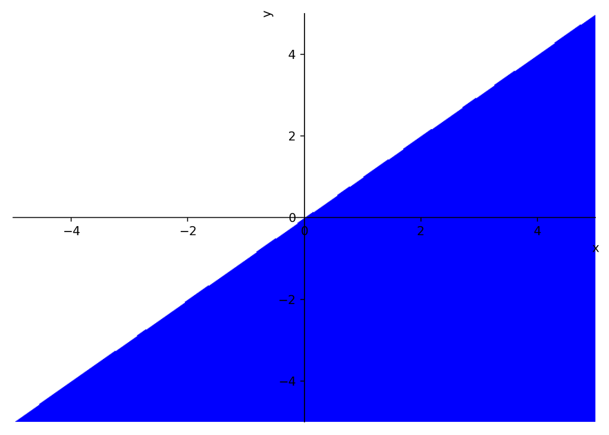

```python
import sympy as sp

x = sp.symbols("x")
y = sp.symbols("y")

p1 = sp.plot_implicit(x>y)
```

*b. $y\le 2$*

Vamos a determinar su resolución a través de código Python.

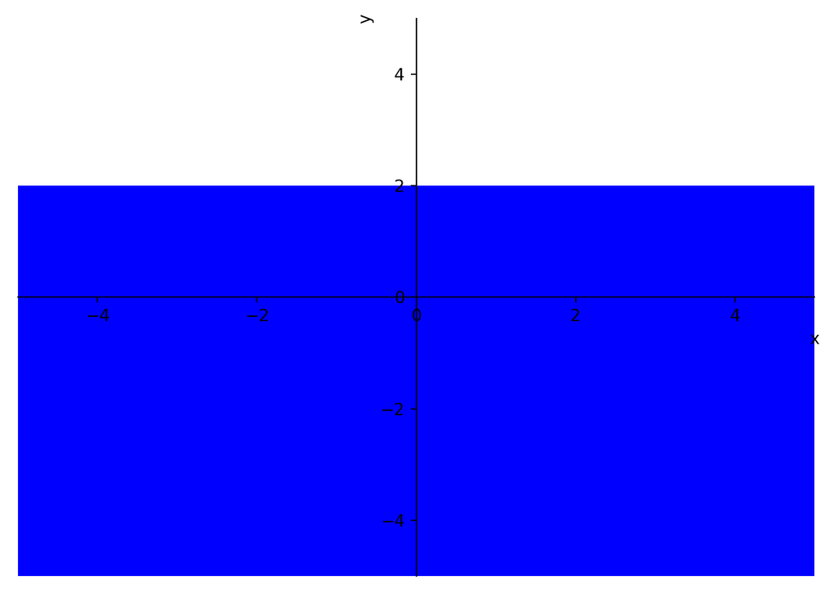

```python
import sympy as sp

x = sp.symbols("x")
y = sp.symbols("y")

p1 = sp.plot_implicit(y<=2,x)
```

*c. $|x-y| < 1$*

Vamos a determinar su resolución a través de código Python.

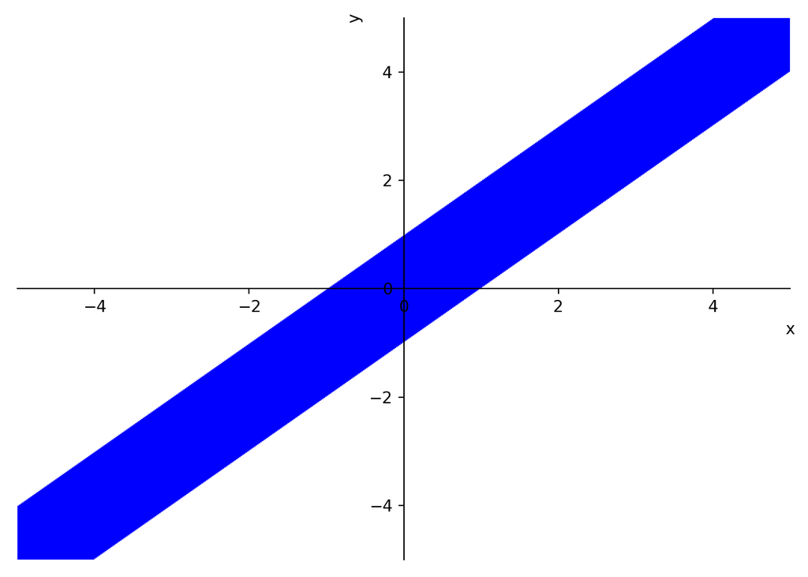

```python
import sympy as sp

x = sp.symbols("x")
y = sp.symbols("y")

p1 = sp.plot_implicit(abs(x-y)<1)
```

## 10. Representa graficamente los conjuntos de puntos (x, y) tales que:

*a. $|x| + |y| = 1$*

Vamos a determinar su resolución a través de código Python.

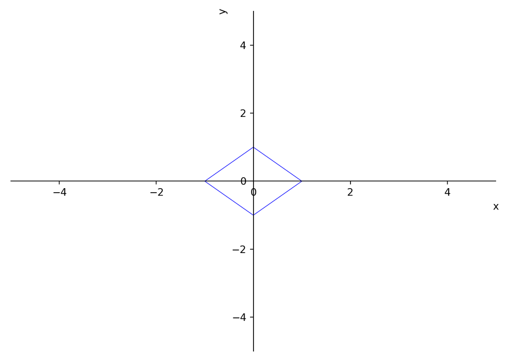

```python
import sympy as sp

x = sp.symbols("x")
y = sp.symbols("y")

expr = abs(x)+abs(y) -1

p1 = sp.plot_implicit(expr)
```

*b. $|x-1| = |y-1|$*

Vamos a determinar su resolución a través de código Python.

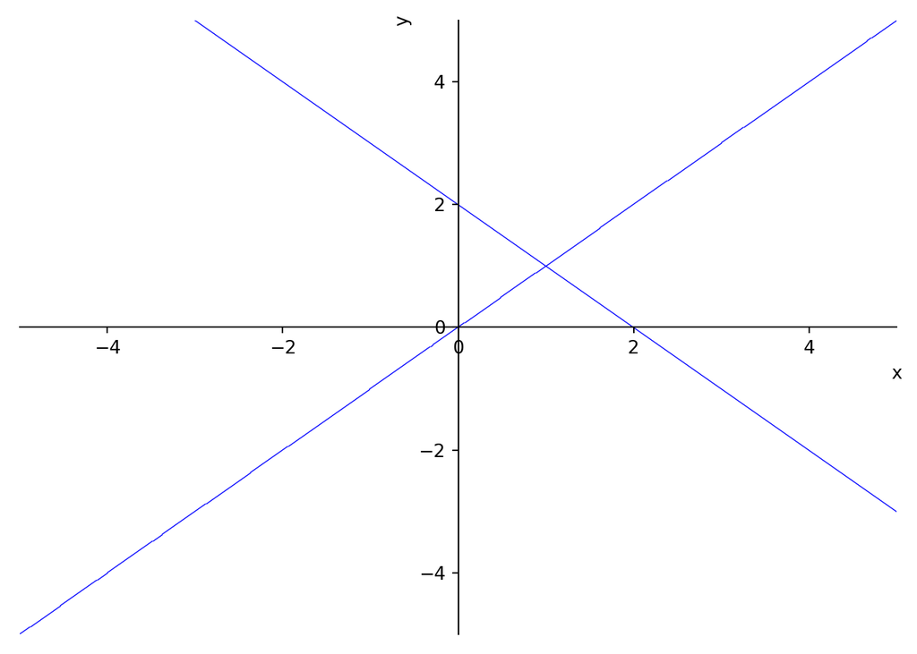

```python
import sympy as sp

x = sp.symbols("x")
y = sp.symbols("y")

expr = abs(x-1)-abs(y-1)

p1 = sp.plot_implicit(expr)
```

*c. $x\cdot y = 0$*

Vamos a determinar su resolución a través de código Python.

[figure not shown]

```python
import sympy as sp

x = sp.symbols("x")
y = sp.symbols("y")

expr = x*y

p1 = sp.plot_implicit(x*y, color="red",lw=5)
```

## 11. Representa graficamente los conjuntos de puntos (x, y) tales que:

*a. $y = 2 - \frac{|x|}{x}$*

Vamos a determinar su resolución a través de código Python.

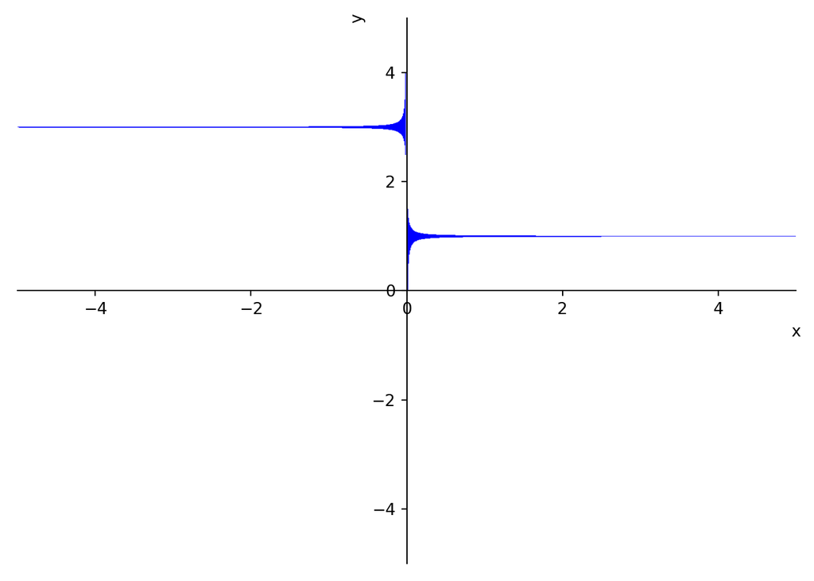

```python
import sympy as sp

x = sp.symbols("x")
y = sp.symbols("y")

expr = y-2+(abs(x)/x)

p1 = sp.plot_implicit(expr, color="red",lw=5)
```

*b. $(x-1)^2 + (y-3)^2 < 1$*

Vamos a determinar su resolución a través de código Python.

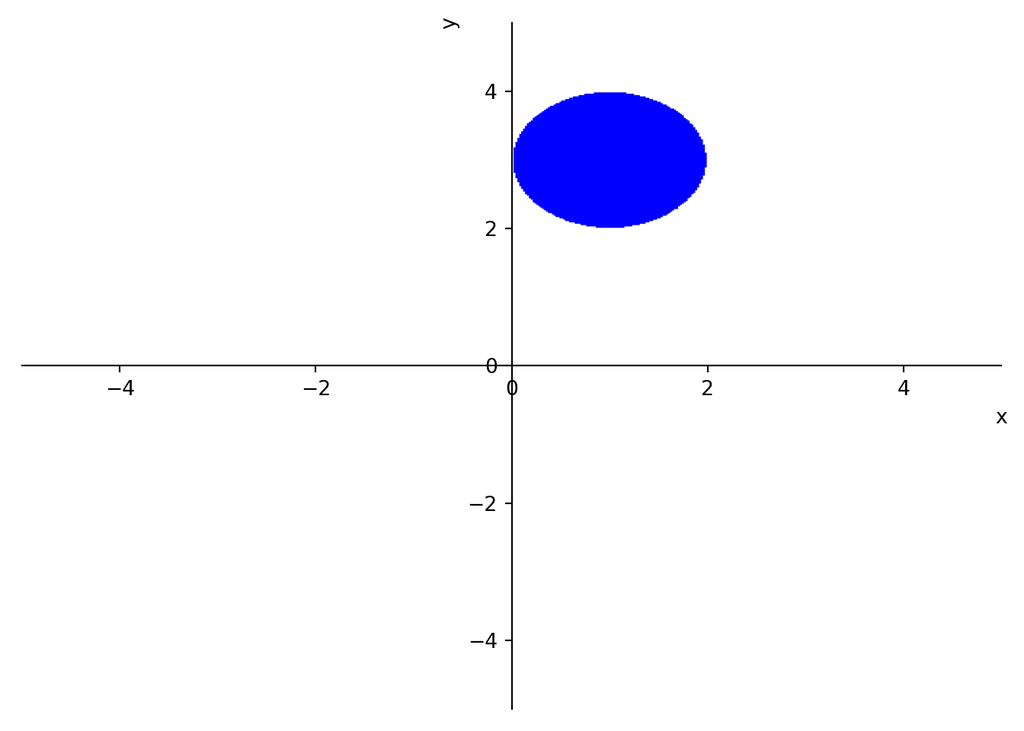

```python
import sympy as sp

x = sp.symbols("x")
y = sp.symbols("y")

expr = (x-1)**2 + (y-3)**2

p1 = sp.plot_implicit(expr<1, color="red")
```

*c. $\frac{x^2}{4}+\frac{y^2}{9} = 1$*

Vamos a determinar su resolución a través de código Python.

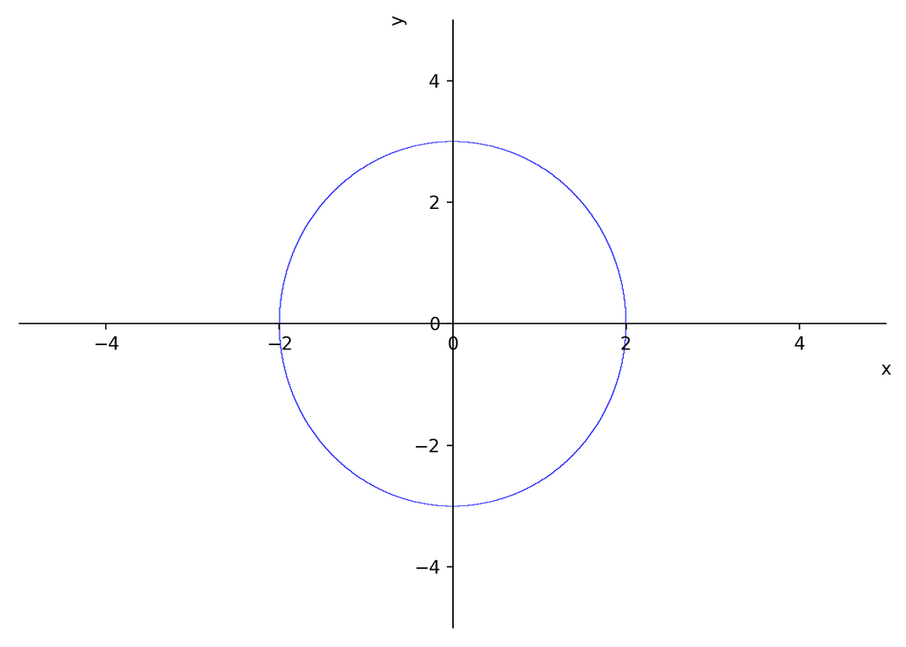

```python
import sympy as sp

x = sp.symbols("x")
y = sp.symbols("y")

expr = ((x**2)/4) + ((y**2)/9) - 1

p1 = sp.plot_implicit(expr, color="red")
```